# Random Forest

2021-05-12

# 一、input

- 参考：https://www.listendata.com/2014/11/random-forest-with-r.html#Random-Forest-R-Code
- 原始数据位于http://archive.ics.uci.edu/ml/datasets/Heart+Disease

```r
rm(list = ls())
options(stringsAsFactors = F)
library(ggplot2)
#BiocManager::install('randomForest')
library(randomForest)
## randomForest 4.6-14
## Type rfNews() to see new features/changes/bug fixes.
##
## Attaching package: 'randomForest'
## The following object is masked from 'package:ggplot2':
##
##     margin

url <- "http://archive.ics.uci.edu/ml/machine-learning-databases/heart-disease/processed.cleveland.data"
data <- read.csv(url, header=FALSE)
```

# 二、clean

- 自变量有连续，分类两种
- 然后我们使用str(data)看一下此时的数据结构可以发现不规范的变量有，
- sex：应该是因子变量，0代表女，1代表男；
- cp、fbs、restecg、exang、slope：应该是因子变量；
- ca：应该使用“NA”表示缺失值，而不是“？”；
- thal：和ca情况一样；
- hd：因子变量，0是健康，1是心脏病；

```r
# 取回的数据没有列名
head(data)
```

```
##   V1 V2 V3  V4  V5 V6 V7  V8 V9 V10 V11 V12 V13 V14
## 1 63  1  1 145 233  1  2 150  0 2.3   3 0.0 6.0   0
## 2 67  1  4 160 286  0  2 108  1 1.5   2 3.0 3.0   2
## 3 67  1  4 120 229  0  2 129  1 2.6   2 2.0 7.0   1
## 4 37  1  3 130 250  0  0 187  0 3.5   3 0.0 3.0   0
## 5 41  0  2 130 204  0  2 172  0 1.4   1 0.0 3.0   0
## 6 56  1  2 120 236  0  0 178  0 0.8   1 0.0 3.0   0
```

```r
# 手动修改列名
colnames(data) <- c(
  "age",  "sex",  "cp",   "trestbps",
  "chol",   "fbs",    "restecg",
  "thalach",   "exang",    "oldpeak",
  "slope",  "ca",   "thal",  "hd"
) # 共14个

head(data)
```

```
##   age sex cp trestbps chol fbs restecg thalach exang oldpeak slope  ca thal hd
## 1  63   1  1      145  233   1       2     150     0     2.3     3 0.0  6.0  0
## 2  67   1  4      160  286   0       2     108     1     1.5     2 3.0  3.0  2
## 3  67   1  4      120  229   0       2     129     1     2.6     2 2.0  7.0  1
## 4  37   1  3      130  250   0       0     187     0     3.5     3 0.0  3.0  0
## 5  41   0  2      130  204   0       2     172     0     1.4     1 0.0  3.0  0
## 6  56   1  2      120  236   0       0     178     0     0.8     1 0.0  3.0  0
```

```r
#先将“？”更换为“NA”
data[data=="?"]<-NA

#将sex修改为正确的因子变量，并处理好性别
data$sex <- factor(data$sex,levels = c(0,1), labels = c("F","M"))
#将cp、fbs、restecg、exang、slope修改为因子变量
data$cp <- as.factor(data$cp)
data$fbs <- as.factor(data$fbs)
data$restecg <- as.factor(data$restecg)
data$exang <- as.factor(data$exang)
data$slope <- as.factor(data$slope)

#由于ca刚开始使用的’？‘代表的缺失值，因此ca里面的变量都是字符类型的因子变量
#因此需要先转换为数值型，再进行因子变量转换
data$ca <- as.integer(data$ca)
data$ca <- as.factor(data$ca)
#同理，将thal做同样处理
data$thal <- as.integer(data$thal)
data$thal <- as.factor(data$thal)

#将hd修改为因子变量，0为健康，1为不健康
data$hd <- ifelse(data$hd == 0, "Healthy", "Unhealthy")
data$hd <- as.factor(data$hd)

head(data)
```

```
##   age sex cp trestbps chol fbs restecg thalach exang oldpeak slope ca thal
## 1  63   M  1      145  233   1       2     150     0     2.3     3  0    6
## 2  67   M  4      160  286   0       2     108     1     1.5     2  3    3
## 3  67   M  4      120  229   0       2     129     1     2.6     2  2    7
## 4  37   M  3      130  250   0       0     187     0     3.5     3  0    3
## 5  41   F  2      130  204   0       2     172     0     1.4     1  0    3
## 6  56   M  2      120  236   0       0     178     0     0.8     1  0    3
##          hd
## 1   Healthy
## 2 Unhealthy
## 3 Unhealthy
## 4   Healthy
## 5   Healthy
## 6   Healthy
```

# 三、random forest

- rfImpute填补缺失值
- rfImpute函数用于填补缺失值，随机森林的缺失值填补是根据相似度进行填补的一种迭代算法
- 简单来说，缺失值会首先根据数据类别不同进行填充，也就是数值数据填充当前变量的中位数，分类数据填充当前变量的众数。然后构建随机森林，并根据随机森林来决定所有的记录之间的相似度，最后根据相似度和当前变量的其他数据对缺失值进行填补。
- 一般上述过程会迭代4-6次，4-6次被认为是比较合理的迭代次数。
- R中ifImpute函数默认创建300棵决策树的随机森林。
- 最佳子集数目根据数据类别不同进行设定，数值数据为总变量数除以3，分类数据为总变量数的平方根。
- 结果会输出每次迭代后的OOB值，越低越好。

```r
# rfImpute填补缺失值
# hd~. 其中hd为相应变量，.为其他所有变量，其意义为使用其他所有变量预测hd
data.imputed <- rfImpute(hd ~ ., data = data, iter=6)
## ntree      OOB      1      2
##   300:  18.48% 15.85% 21.58%
## ntree      OOB      1      2
##   300:  17.49% 13.41% 22.30%
## ntree      OOB      1      2
##   300:  18.15% 14.63% 22.30%
## ntree      OOB      1      2
##   300:  16.17% 10.98% 22.30%
## ntree      OOB      1      2
##   300:  17.16% 14.02% 20.86%
## ntree      OOB      1      2
##   300:  17.49% 13.41% 22.30%

model <- randomForest(hd ~ ., data=data.imputed, proximity=TRUE)

model
```

```
##
## Call:
##  randomForest(formula = hd ~ ., data = data.imputed, proximity = TRUE)
##                Type of random forest: classification
##                      Number of trees: 500
## No. of variables tried at each split: 3
##
##         OOB estimate of  error rate: 16.5%
## Confusion matrix:
##           Healthy Unhealthy class.error
## Healthy       143        21   0.1280488
## Unhealthy      29       110   0.2086331
```

```r
# proximity参数不是必须的，加上后，则会输出proximity矩阵，此矩阵可用于热图或MDS（PCoA）
```

# 四、评价

- model下err.rate中是OOB的数据，它有三列，分别是总OOB、健康人的OOB以及不健康人的OOB
- 创建数据框用于ggplot绘图
- importance()函数用于计算模型变量的重要性

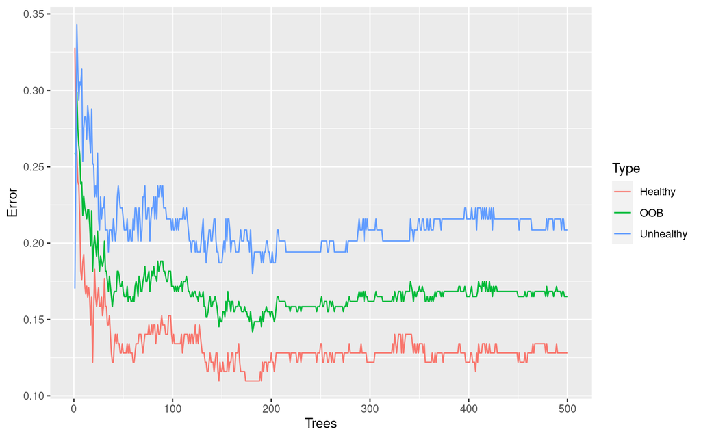

```r
oob.error.data <- data.frame(
  Trees=rep(1:nrow(model$err.rate), times=3),
  Type=rep(c("OOB", "Healthy", "Unhealthy"), each=nrow(model$err.rate)),
  Error=c(model$err.rate[,"OOB"],
          model$err.rate[,"Healthy"],
          model$err.rate[,"Unhealthy"]))
# 绘图
ggplot(oob.error.data, aes(x=Trees, y=Error)) + geom_line(aes(color=Type))
```

```r
#importance()函数用于计算模型变量的重要性
importance(model)
```

```
##          MeanDecreaseGini
## age             12.828263
## sex              4.475173
## cp              20.435842
## trestbps        10.928971
## chol            12.086007
## fbs              1.249997
## restecg          2.784035
## thalach         16.039079
## exang            8.328295
## oldpeak         15.503630
## slope            7.576921
## ca              18.607472
## thal            17.554331
```

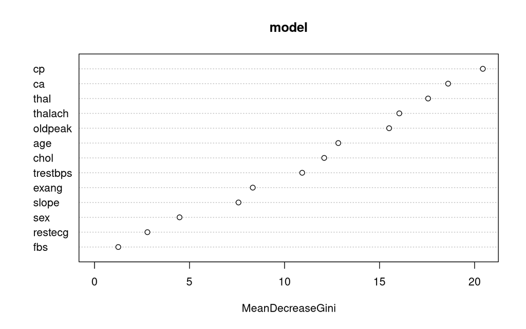

```r
varImpPlot(model)
```

```r
# 看出cp ca两个变量最重要
```

# 五、最优子集

```r
oob.values <- vector(length=10)
for (i in 1:10){
  temp.model <- randomForest(hd~.,data = data.imputed,mtry=i)
  oob.values[i] <- temp.model$err.rate[nrow(temp.model$err.rate),1]
}
oob.values
```

```
##  [1] 0.1518152 0.1716172 0.1848185 0.1716172 0.1848185 0.1881188 0.1782178
##  [8] 0.1848185 0.1914191 0.2046205
```